# Machine Learning with MLR3

Joe Razo

##### [Home](https://jrazo7063.github.io/Homepage.html) | [Statistical Learning](https://jrazo7063.github.io/DissCode.html) | [Data Cleaning](https://jrazo7063.github.io/Data-Cleaning.html) | [Count Dist.](https://www.youtube.com/watch?v=4rVyLQeVDI4) | [Data Visualization](https://www.youtube.com/watch?v=4hu7_zcG83Q)

# The Data

This is a continuation of the statistcal learning methods used on the TEDS dataset. I will be continuing my analysis on this set, while using different algorithms via the `mlr3` environment.

The data can again be found at this [website](https://www.datafiles.samhsa.gov/dataset/teds-d-2017-ds0001-teds-d-2017-ds0001) in order to follow along.

We will clean the data the same way as the previous analysis, using the same features in my dissertation analysis.  
Let’s start with loading and cleaning the data.

## Data Cleaning

```r
library(tidyverse)

teds <- read_csv("tedsd_2017.csv", show_col_types = FALSE)
```

### Transforming all variables

```r
teds <- teds %>%
  mutate(Disch = ifelse(teds$REASON == 1 | teds$REASON ==4,1,0),
         alcohol = case_when(
           teds$SUB1 == 2 ~ 1, # Alcohol is primary drug of choice
           teds$SUB2 == 2 ~ 2, # Alcohol is secondary drug of choice
           teds$SUB3 == 2 ~ 3, # Alcohol is tertiary drug of choice
           TRUE ~ 0),
         alcohol_Benzo = case_when(
           teds$SUB1 == 2 | teds$SUB1 == 13 | teds$SUB1 == 14 ~ 1,
           teds$SUB2 == 2 | teds$SUB2 == 13 | teds$SUB2 == 14 ~ 2,
           teds$SUB3 == 2 | teds$SUB3 == 13 | teds$SUB3 == 14 ~ 3,
           TRUE ~ 0),
         marijuana = case_when(
           teds$SUB1 == 4 ~ 1,
           teds$SUB2 == 4 ~ 2,
           teds$SUB3 == 4 ~ 3,
           TRUE ~ 0),
         Heroin = case_when(
           teds$SUB1 == 5 ~ 1,
           teds$SUB2 == 5 ~ 2,
           teds$SUB3 == 5 ~ 3,
           TRUE ~ 0),
         Her_Op = case_when(
           teds$SUB1 == 5 | teds$SUB1 == 7 ~ 1,
           teds$SUB2 == 5 | teds$SUB2 == 7 ~ 2,
           teds$SUB3 == 5 | teds$SUB3 == 7 ~ 3,
           TRUE ~ 0),
         stimulants = case_when(
           teds$SUB1 == 3 | teds$SUB1 >= 10 & teds$SUB1 <= 12 ~ 1,
           teds$SUB2 == 3 | teds$SUB2 >= 10 & teds$SUB2 <= 12 ~ 2,
           teds$SUB3 == 3 | teds$SUB3 >= 10 & teds$SUB3 <= 12 ~ 3,
           TRUE ~ 0),
         cocaine = case_when(
           teds$SUB1 == 3 ~ 1,
           teds$SUB2 == 3 ~ 2,
           teds$SUB3 == 3 ~ 3,
           TRUE ~ 0),
         Court = ifelse(teds$PSOURCE==7,1,0),
         detox = ifelse(teds$SERVICES==8|teds$SERVICES==1|teds$SERVICES==2,1,0),
         out_pt = ifelse(teds$SERVICES==6|teds$SERVICES==7,1,0),
         resid = ifelse(teds$SERVICES>=3 &teds$SERVICES<=5,1,0)
         )
```

### Keeping only our relevant variables

```r
teds <- teds%>%
  dplyr::select(PSOURCE, LOS, NOPRIOR, ARRESTS, PSYPROB, DSMCRIT, EMPLOY, GENDER, AGE, RACE, ETHNIC, alcohol, marijuana, ROUTE1, ROUTE2, ROUTE3, Heroin, Her_Op, stimulants, FREQ1, FREQ2, FREQ3, FRSTUSE1, FRSTUSE2, FRSTUSE3, cocaine, alcohol_Benzo, out_pt, resid, Court, detox, Disch)
```

### Missing Data

```r
teds<- teds%>%
  mutate(LOS = replace(LOS,LOS==-9,0),
         ROUTE1 = replace(ROUTE1,ROUTE1==-9,0),
         ROUTE2 = replace(ROUTE2,ROUTE2==-9,0),
         ROUTE3 = replace(ROUTE3,ROUTE3==-9,0),
         FREQ1 = replace(FREQ1,FREQ1==-9,1),
         FREQ2 = replace(FREQ2,FREQ2==-9,0),
         FREQ3 = replace(FREQ3,FREQ3==-9,0),
         FRSTUSE1 = replace(FRSTUSE1,FRSTUSE1==-9,0),
         FRSTUSE2 = replace(FRSTUSE2,FRSTUSE2==-9,0),
         FRSTUSE3 = replace(FRSTUSE3,FRSTUSE3==-9,0))

teds[teds==-9]<-NA
teds<-na.omit(teds)
```

### Covnerting to factors

```r
x<- c(1,3:8,10,11,14:16,20:22,32)
teds<-as.data.frame(teds)
for (i in x){
  teds[,i]<-factor(teds[,i])
}
head(teds)
```

```
##   PSOURCE LOS NOPRIOR ARRESTS PSYPROB DSMCRIT EMPLOY GENDER AGE RACE ETHNIC
## 1       1  37       1       0       1       4      2      2   9    5      4
## 2       3  36       1       0       2      15      1      2   9    5      4
## 3       7  33       0       0       2       9      1      1   7    5      4
## 4       7  32       1       1       1       4      4      1  12    1      4
## 5       7  36       0       0       2       4      1      1   6    8      4
## 6       1  36       0       0       1      14      2      1   5    5      4
##   alcohol marijuana ROUTE1 ROUTE2 ROUTE3 Heroin Her_Op stimulants FREQ1 FREQ2
## 1       1         0      1      2      1      0      3          0     3     3
## 2       0         0      2      1      0      0      2          1     1     1
## 3       1         0      1      0      0      0      0          0     2     0
## 4       2         1      2      1      0      0      0          0     3     3
## 5       1         2      1      2      0      0      0          0     2     3
## 6       1         0      1      0      0      0      0          0     2     0
##   FREQ3 FRSTUSE1 FRSTUSE2 FRSTUSE3 cocaine alcohol_Benzo out_pt resid Court
## 1     3        0        0        0       0             1      1     0     0
## 2     0        7        4        0       0             0      1     0     0
## 3     0        4        0        0       0             1      1     0     1
## 4     0        0        0        0       0             2      1     0     1
## 5     0        1        2        0       0             1      1     0     1
## 6     0        5        0        0       0             1      1     0     0
##   detox Disch
## 1     0     1
## 2     0     0
## 3     0     1
## 4     0     1
## 5     0     1
## 6     0     0
```

### Data Splitting

```r
set.seed(2023)
split <- sample(1:5, nrow(teds), replace = TRUE)

teds.RF <- teds%>%filter(split==1)
teds.LAR <- teds%>%filter(split==2)
teds.LoR <- teds%>%filter(split==3)
teds.Sp <- teds%>% filter(split==4)
teds.NN <- teds%>% filter(split==5)

### Training/Test Sets
set.seed(2023)
RF.test = sample(nrow(teds.RF), nrow(teds.RF)*.2)
LAR.test = sample(nrow(teds.LAR), nrow(teds.LAR)*.2)
LoR.test = sample(nrow(teds.LoR), nrow(teds.LoR)*.2)
Sp.test = sample(nrow(teds.Sp), nrow(teds.Sp)*.2)
NN.test = sample(nrow(teds.NN), nrow(teds.NN)*.2)
```

# MLR3

The `mlr3` suite is host to a series of great functions capable of handling most machine learning algorithms. I truly enjoy this family due to its easy to use functionality that makes automatically training your model a breeze! We won’t go into the full power of the `mlr3verse`, which includes pipeops designed to seamlessly expand your model, by assisting with preprocessing, running parallel models, and much more.

In this demo we will use the random forest package `ranger`, which has garnered a reputation of being much faster than its counterpart package `randomForest`. We will tune our model using 3 different hyperparameters, assess classification accuracy using sensitivity/specificity, PPV/NVP, and ROC/AUC.

```r
library(mlr3)
library(mlr3learners)
library(mlr3tuning)
library(paradox)
```

## Prepping our data

The `mlr3` environment requires you to transform your dataframe (typically in S3 format) into an R6 format, commonly referred to as “tasks”. Depending on your research question, your task will typically take the form of `TaskClassif` for classification problems, `TaskRegr` for regression or `TaskSurv` for survival analysis. *For more classes, refer to the [mlr3 book](https://mlr3book.mlr-org.com/basics.html#tasks).

Here we will use the `TaskClassif`.

```r
train.dat <- as_task_classif(target = "Disch",teds.RF[-RF.test,])
test.dat <- as_task_classif(target = "Disch", teds.RF[RF.test,])
```

## Building our model

Under the `mlr3` umbrella, algorithms are classified as “learners”. Further, not all learners are native in `mlr3`, some reside in the packages `mlr3learners` or `mlr3extralearners`. The `ranger` learner lives in the `mlr3learners` package. For a comprehensive list, refer the the [mlr3verse learners](https://mlr3extralearners.mlr-org.com/articles/learners/list_learners.html) page.

We will use the `classif.ranger` learner, given that our problem is a classification one. There are `regr.ranger` and `surv.ranger` for regression and survival random forests, respectively.

Next we will set up our search space using the `ps()` function. This provides the algorithm the values to search within to test our hyperparameters. For example, the `ranger` model will use varying values from 1 to 10 for the mtry parameter.

Here’s a quick review of the hyperparamters for a `ranger` model:

- `mtry` : The number of variables to possibly split at in each node.
- `num.trees` : number of trees.
- `max.depth` : Maximal tree depth

Finally, we need to tell the model when to terminate the search for the best model. We do this with the `trm` function, where we used the command “stagnation” and set the threshold to .001. This tells the `AutoTuner` to stop searching our seach space when the model does not improve more than .001 AUC. For other `Terminator` methods, see [Abstract Terminator Class](https://bbotk.mlr-org.com/reference/Terminator.html)

```r
mlr_learners$get("classif.ranger")
```

```
## <LearnerClassifRanger:classif.ranger>
## * Model: -
## * Parameters: num.threads=1
## * Packages: mlr3, mlr3learners, ranger
## * Predict Type: response
## * Feature types: logical, integer, numeric, character, factor, ordered
## * Properties: hotstart_backward, importance, multiclass, oob_error,
##   twoclass, weights
```

```r
learner <- lrn("classif.ranger", write.forest = TRUE, predict_type = "prob")

search_space <- ps(
  mtry = p_int(lower = 1, upper = 10),
  num.trees = p_int(lower = 100, upper = 1000),
  max.depth = p_int(lower = 1, upper = 6)
)
terminate = trm("stagnation", threshold = .001)
```

## Training/Tuning

This has got to be hands down my favorite part of the `mlr3` family. The `AutoTuner` function makes quick work of training and tuning your model. We already did most of the leg work in the previous step to set up the tuning, so it’s just a matter of plugging them in.

The only things we need to specify here are the resampling method, the measurement metric, and the tuner type. I chose 10-fold cross validation, but you can just as easily use bootstrapping or any other method referenced [here](https://mlr3.mlr-org.com/reference/mlr_resamplings.html). I chose the `classif.auc` metric, however there are many more options outlined [here](https://mlr3measures.mlr-org.com/reference/index.html). Lastly, I used the “random_search” tuner.

```r
autotune <- AutoTuner$new(
  learner = learner,
  search_space = search_space,
  resampling = rsmp("cv", folds = 10),
  measure = msr("classif.auc"),
  terminator = terminate,
  tuner = tnr("random_search")
)
```

### Training

All that’s left is to train the model using the training dataset we created earlier.

```r
set.seed(1234)
autotune$train(train.dat)
```

Once that’s done we can use the `predict` function built into the `AutoTuner` to gather accuracy, as well as a whole host of information. Here we’re going to look at the test AUC.

```r
rforest.pred <- autotune$predict(test.dat)
measure <- msr("classif.auc")

rforest.pred$score(measure)
```

```
## classif.auc
##    0.729857
```

Next, well pull the confusion matrix.

```r
rforest.pred$confusion
```

```
##         truth
## response     0     1
##        0  3630  2105
##        1  8161 18199
```

Though the confusion matrix is helpful, I like to know what my sensitivity, specificity, Positive Predictive Value (PPV), and Negative Predictive Value (NPV) are. I created a few simple functions to gather this information much easier:

```r
specificity <- function(x){
  x[1,1]/sum(x[,1])
}
sensitivity <- function(x){
  x[2,2]/sum(x[,2])
}
PPV<- function(x){
  x[2,2]/sum(x[2,])
}
NPV<- function(x){
  x[1,1]/sum(x[1,])
}
```

Now let’s take a look…

```r
sensitivity(rforest.pred$confusion)
```

```
## [1] 0.8963258
```

```r
specificity(rforest.pred$confusion)
```

```
## [1] 0.3078619
```

```r
PPV(rforest.pred$confusion)
```

```
## [1] 0.6904021
```

```r
NPV(rforest.pred$confusion)
```

```
## [1] 0.6329555
```

It’s important to note that the default threshold for the prediction class is set to .5, which can drastically impact the performance on the confusion matrix. Fortunately, the predicted class has an option to set the threshold manually called `set_threshold`. Thus, if you would like to increase the positive case threshold to get a more balanced confusion matrix, you would simply call `rforest.pred$set_threshold()` and specify your desired threshold.

Lastly, we’ll take a look at our ROC plot:

```r
library(AUC)
```

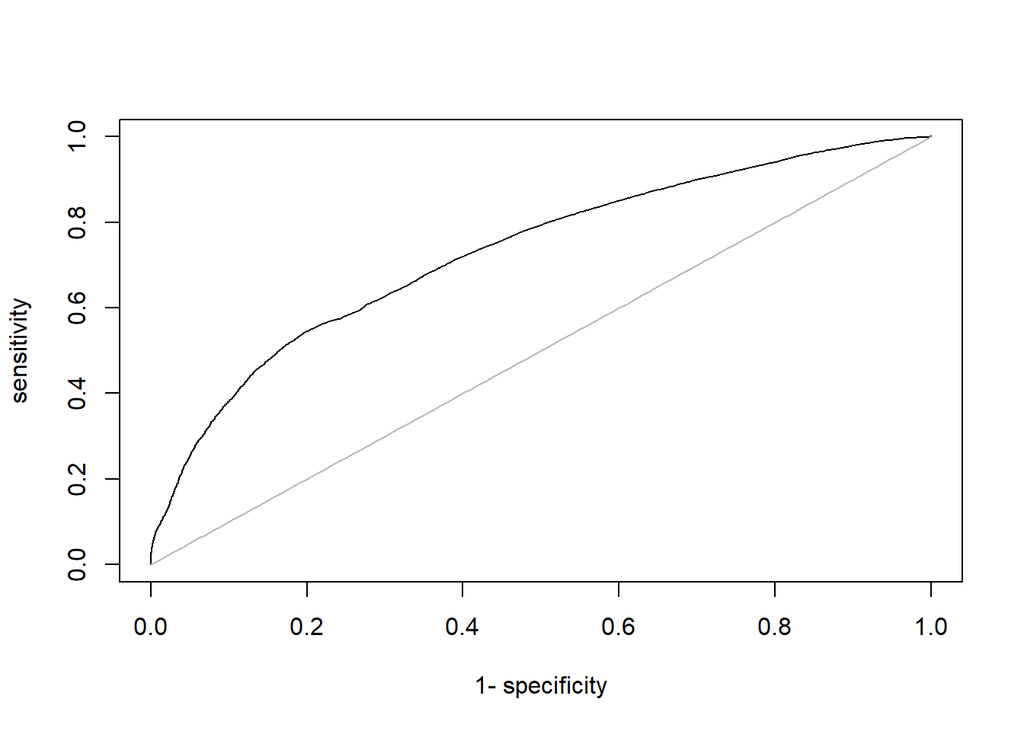

```r
plot(roc(rforest.pred$prob[,2], rforest.pred$truth))
```